# heat map

## 1 Introduction

Email from Baydoun, May Ahmad on May 12, 2023.

**Instructions in May’s email**

I am almost done with the analysis for the new paper and I met with Osorio to finalize it. I am attaching the excel sheet for the heat map that I need from you.

Basically, it has to be labelled with 22 different proteins (gdf15 etc…), the variables to be included are the Beta which should be labelled as : Tereri ereri_cde ereri_intref ereri_intmed ereri_pie pct_cde pct_intref pct_intmed pct_pie

Finally, it would nice to have an asterisk for P<0.05 for: Tereri ereri_cde ereri_intref ereri_intmed ereri_pie

Notice that pct variables are percentages, so they should add up to 100% per protein.

Please let me know if you have any questions or issues.

As I told Osorio, it would be great to have this done by June 20th.

This is a hot topic and a lot of people will be diving into this data 😊. Thank you for all your hard work,

Have a nice weekend,

Further explanations from May on May 17, 2023.

**Further instructions in May’s email**

Just as a clarification, the legend for pct should be from -10% to +10%, since most pcts are between 0 and 7% in either direction.

The other one which includes the total effect (tereri), pure indirect effect (pie), controlled direct effect (cde) and the two other components (interaction referent and mediated interaction), should be from -2 to +2, since the total effect is about 1.2 to 1.5 and the others are simply components of that total effect.

The cde and te are close enough to each other in color, but cde should be somehow lighter than te.

For the stars (*), those are mainly for all the te, cde and most of the pie (with 5 exceptions, since 17 of the 22 have significant PIE).

## 2 Load data

```r
d <- read_excel("../File_from_May/TOP22_FOURWAYDECOMPOSITION_FINDINGS_FINAL.xlsx", sheet = "HEATMAP_DATA") |>
  clean_names()


glimpse(d)
```

```
Rows: 198
Columns: 8
$ fourwaydecomp <chr> "tereri", "ereri_cde", "ereri_intref", "ereri_intmed", "…
$ beta          <dbl> 1.28714300, 1.14491900, -0.00068420, 0.05538480, 0.08752…
$ se            <dbl> 0.1712100, 0.1750251, 0.0108466, 0.0314500, 0.0138307, N…
$ z             <dbl> 7.52, 6.54, -0.06, 1.76, 6.33, NA, NA, NA, NA, 7.55, 7.0…
$ p             <dbl> 0.000, 0.000, 0.950, 0.078, 0.000, NA, NA, NA, NA, 0.000…
$ lcl           <dbl> 0.9515776, 0.8018756, -0.0219431, -0.0062560, 0.0604163,…
$ ucl           <dbl> 1.6227090, 1.4879610, 0.0205746, 0.1170256, 0.1146316, N…
$ protein       <chr> "gdf15", "gdf15", "gdf15", "gdf15", "gdf15", "gdf15", "g…
```

## 3 data reorganizing

### 3.1 Convert to wide format

beta value

```r
d_wide <-
  d |>
  select(fourwaydecomp, beta, protein, p) |>
  pivot_wider(
    id_cols = protein,
    # id_cols = c(protein, p),
    names_from = fourwaydecomp,
    values_from = beta
  )

glimpse(d_wide)
```

```
Rows: 22
Columns: 10
$ protein      <chr> "gdf15", "igfbp4", "wfdc2", "vsig4", "eda2r", "col6ar", "…
$ tereri       <dbl> 1.287143, 1.268780, 1.295011, 1.264725, 1.328822, 1.25494…
$ ereri_cde    <dbl> 1.144919, 1.229168, 1.248344, 1.240798, 1.250763, 1.21283…
$ ereri_intref <dbl> -0.0006842, -0.0016791, -0.0067778, -0.0019611, -0.003934…
$ ereri_intmed <dbl> 0.0553848, 0.0154409, -0.0006789, -0.0009057, 0.0261834, …
$ ereri_pie    <dbl> 0.0875240, 0.0258498, 0.0541230, 0.0267940, 0.0558096, 0.…
$ pct_cde      <dbl> 88.95041, 96.87795, 96.39640, 98.10813, 94.12570, 96.6447…
$ pct_intref   <dbl> -0.05315649, -0.13233973, -0.52337779, -0.15506138, -0.29…
$ pct_intmed   <dbl> 4.30292516, 1.21698797, -0.05242427, -0.07161241, 1.97042…
$ pct_pie      <dbl> 6.7998661, 2.0373745, 4.1793467, 2.1185633, 4.1999305, 2.…
```

p value

```r
d_wide_p <-
  d |>
      mutate(
      p_anno = case_when(
         p <= 0.001 ~ "***",
         p <= 0.01 ~ "**",
         p <= 0.05 ~ "*",
         .default = ""
      )
   ) |>
  select(fourwaydecomp, beta, protein, p_anno) |>
  pivot_wider(
    id_cols = protein,
    # id_cols = c(protein, p),
    names_from = fourwaydecomp,
    values_from = p_anno
  )

glimpse(d_wide_p)
```

```
Rows: 22
Columns: 10
$ protein      <chr> "gdf15", "igfbp4", "wfdc2", "vsig4", "eda2r", "col6ar", "…
$ tereri       <chr> "***", "***", "***", "***", "***", "***", "***", "***", "…
$ ereri_cde    <chr> "***", "***", "***", "***", "***", "***", "***", "***", "…
$ ereri_intref <chr> "", "", "", "", "", "", "", "", "", "", "", "", "", "", "…
$ ereri_intmed <chr> "", "", "", "", "", "", "", "", "", "", "", "", "", "", "…
$ ereri_pie    <chr> "***", "*", "***", "*", "***", "*", "*", "***", "", "**",…
$ pct_cde      <chr> "", "", "", "", "", "", "", "", "", "", "", "", "", "", "…
$ pct_intref   <chr> "", "", "", "", "", "", "", "", "", "", "", "", "", "", "…
$ pct_intmed   <chr> "", "", "", "", "", "", "", "", "", "", "", "", "", "", "…
$ pct_pie      <chr> "", "", "", "", "", "", "", "", "", "", "", "", "", "", "…
```

### 3.2 Convert to matrix

beta

```r
# Convert to matrix
mat <-
  d_wide |>
  select(- contains("pct_")) |>
  column_to_rownames("protein") |>
  as.matrix()

# Order the columns by their means
mat <- mat[, order(colMeans(mat), decreasing = TRUE)]

glimpse(mat)
```

```
 num [1:22, 1:5] 1.29 1.27 1.3 1.26 1.33 ...
 - attr(*, "dimnames")=List of 2
  ..$ : chr [1:22] "gdf15" "igfbp4" "wfdc2" "vsig4" ...
  ..$ : chr [1:5] "tereri" "ereri_cde" "ereri_pie" "ereri_intmed" ...
```

p value

```r
# Convert to matrix
mat_p <-
  d_wide_p |>
  select(- contains("pct_")) |>
  column_to_rownames("protein") |>
  as.matrix()

# Order the columns according to mat
mat_p <- mat_p[, colnames(mat)]

glimpse(mat_p)
```

```
 chr [1:22, 1:5] "***" "***" "***" "***" "***" "***" "***" "***" "***" ...
 - attr(*, "dimnames")=List of 2
  ..$ : chr [1:22] "gdf15" "igfbp4" "wfdc2" "vsig4" ...
  ..$ : chr [1:5] "tereri" "ereri_cde" "ereri_pie" "ereri_intmed" ...
```

## 4 Heatmap

### 4.1 Row ordering

```r
# o1 = seriate(dist(mat), method = "OLO")
# o1 = seriate(dist(mat), method = "MDS")
o1 = seriate(dist(mat), method = "MDS_angle")
```

### 4.2 Use full names as matrix column names

```r
# abbr. name = full name
ef_name <- c("tereri" = "total effect",
             "ereri_cde" = "controlled direct effect",
             "ereri_pie" = "pure indirect effect",
             "ereri_intmed" = "mediated interaction",
             "ereri_intref" = "interaction reference")

colnames(mat) <-  ef_name[colnames(mat)]
```

### 4.3 Make heatmap

- p value annotation.
  - p <= 0.05: *
  - p <= 0.01: **
  - p <= 0.001: ***

#### Scheme I

- Color: RColorBrewer, RdYlBu
- Range: -0.02, 1.3

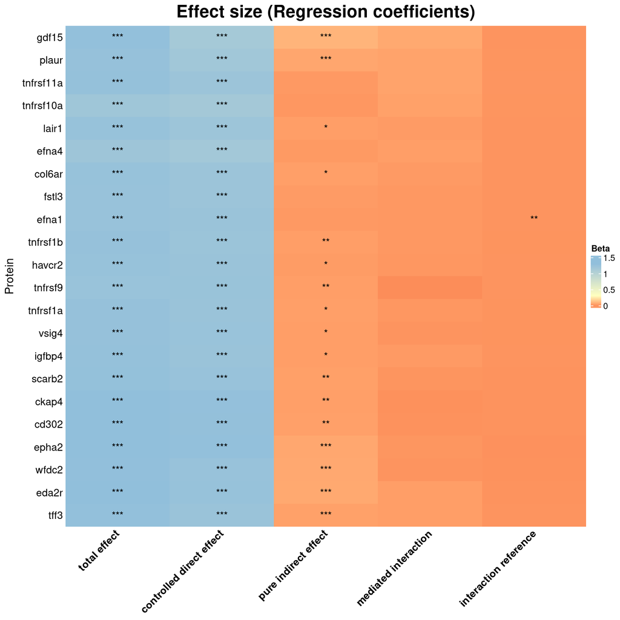

```r
# col_fun = colorRamp2(c(-2, 0.1, 2), brewer.pal(3, "RdYlBu"))
# brewer.pal(3, "RdYlBu") |>
#    scales::show_col()
col_fun = colorRamp2(c(-0.02, 0.3, 1.3), brewer.pal(3, "RdYlBu"))

mat |>
  Heatmap(
   name = "Beta",
   cluster_columns = FALSE,
   cluster_rows = FALSE,
   row_order = get_order(o1),

   # color function
   col = col_fun,

   # Title
   row_title = "Protein",
   row_title_side = "left",
   column_title = "Effect size (Regression coefficients)",
   column_title_gp = gpar(fontsize = 20, fontface = "bold"),

   # Names
   row_names_side = "left",
   column_names_gp = gpar(fontsize = 12, fontface="bold"),
   column_names_rot = 45,

   # Add "*" for significant p values
   cell_fun = function(j, i, x, y, w, h, col) { # add text to each grid
        grid.text(mat_p[i, j], x, y)
    }
  )
```

#### Scheme II

- Color: RColorBrewer, RdYlBu
- Range: -2, 2

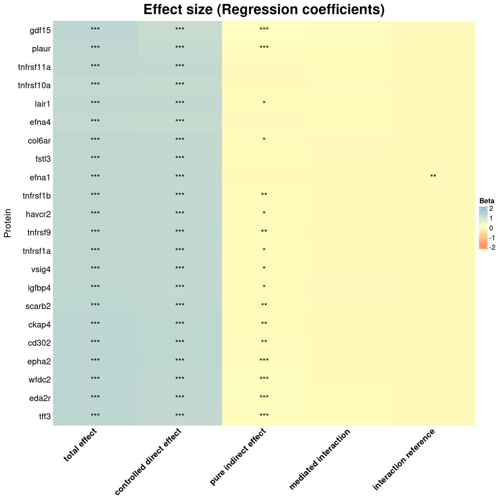

```r
col_fun = colorRamp2(c(-2, 0.1, 2), brewer.pal(3, "RdYlBu"))
# col_fun = colorRamp2(c(-0.02, 0.3, 1.3), brewer.pal(3, "RdYlBu"))

mat |>
  Heatmap(
   name = "Beta",
   cluster_columns = FALSE,
   cluster_rows = FALSE,
   row_order = get_order(o1),

   # color function
   col = col_fun,

   # Title
   row_title = "Protein",
   row_title_side = "left",
   column_title = "Effect size (Regression coefficients)",
   column_title_gp = gpar(fontsize = 20, fontface = "bold"),

   # Names
   row_names_side = "left",
   column_names_gp = gpar(fontsize = 12, fontface="bold"),
   column_names_rot = 45,

   # Add "*" for significant p values
   cell_fun = function(j, i, x, y, w, h, col) { # add text to each grid
        grid.text(mat_p[i, j], x, y)
    }
  )
```

#### Scheme III

- Color: viridis
- Range: -0.02, 1.3

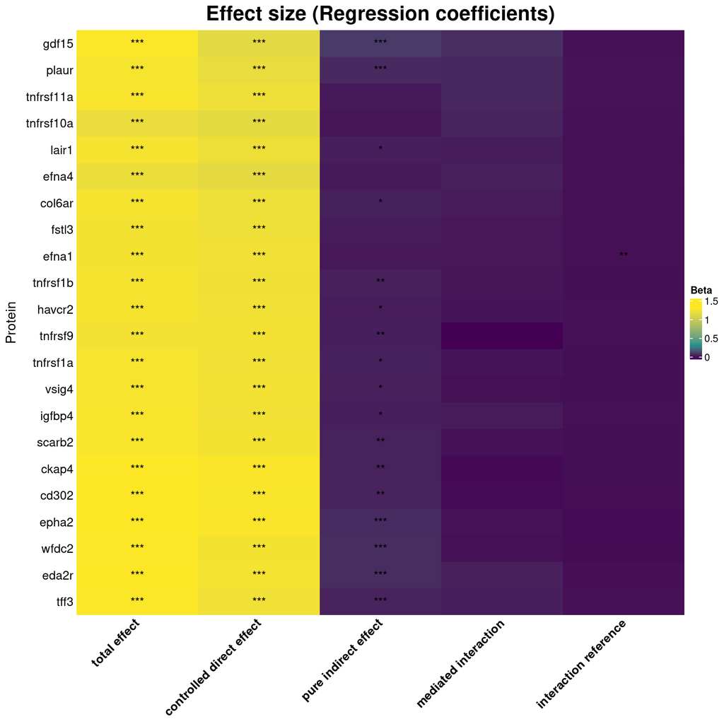

```r
col_fun = colorRamp2(c(-0.02, 0.3, 1.3), viridis(n=3, option = "D"))

mat |>
  Heatmap(
   name = "Beta",
   cluster_columns = FALSE,
   cluster_rows = FALSE,
   row_order = get_order(o1),

   # color function
   col = col_fun,

   # Title
   row_title = "Protein",
   row_title_side = "left",
   column_title = "Effect size (Regression coefficients)",
   column_title_gp = gpar(fontsize = 20, fontface = "bold"),

   # Names
   row_names_side = "left",
   column_names_gp = gpar(fontsize = 12, fontface="bold"),
   column_names_rot = 45,

   # Add "*" for significant p values
   cell_fun = function(j, i, x, y, w, h, col) { # add text to each grid
        grid.text(mat_p[i, j], x, y)
    }
  )
```